# Bay Wheels Data Exploration

## By Tony Randrianavony

This dataset is the Bay Wheels (previously known as Ford GoBike) Dataset that includes information about individual rides make in a bike sharing system covering the greater San Francisco. In this investigation, I wanted to find characteristics and common behaviors between the users.

## What is the structure of your dataset?

Each trip from the dataframe is itemized by multiple categories. Where my main features of interest include the start and end time , the duration and the type of users.

```python
#Making sure there is no more missing values
df_clean.sample(5).T
```

|  | 7112958 | 1783295 | 1591214 | 6560276 | 6464217 |
| --- | --- | --- | --- | --- | --- |
| Unnamed: 0 | 7112958 | 1783295 | 1591214 | 6560276 | 6464217 |
| duration_sec | 1086 | 625 | 390 | 456 | 844 |
| start_time | 2018-04-08 11:14:08.777000 | 2018-09-22 12:40:55.427000 | 2018-08-23 09:23:01.988000 | 2017-09-03 11:10:33.524000 | 2017-10-02 08:33:00.112000 |
| end_time | 2018-04-08 11:32:14.910000 | 2018-09-22 12:51:20.567000 | 2018-08-23 09:29:32.932000 | 2017-09-03 11:18:09.829000 | 2017-10-02 08:47:04.719000 |
| start_station_id | 183.0 | 107.0 | 15.0 | 58.0 | 66.0 |
| start_station_name | Telegraph Ave at 19th St | 17th St at Dolores St | San Francisco Ferry Building (Harry Bridges Pl... | Market St at 10th St | 3rd St at Townsend St |
| start_station_latitude | 37.8087 | 37.763 | 37.7954 | 37.7766 | 37.7787 |
| start_station_longitude | -122.27 | -122.426 | -122.394 | -122.417 | -122.393 |
| end_station_id | 210.0 | 58.0 | 28.0 | 45.0 | 14.0 |
| end_station_name | 45th St at Manila | Market St at 10th St | The Embarcadero at Bryant St | 5th St at Howard St | Clay St at Battery St |
| end_station_latitude | 37.8333 | 37.7766 | 37.7872 | 37.7818 | 37.795 |
| end_station_longitude | -122.256 | -122.417 | -122.388 | -122.405 | -122.4 |
| bike_id | 818.0 | 17.0 | 1067.0 | 2029.0 | 58.0 |
| user_type | Subscriber | Subscriber | Subscriber | Subscriber | Subscriber |
| bike_share_for_all_trip | No | No | No | NaN | NaN |
| rental_access_method | NaN | NaN | NaN | NaN | NaN |
| is_equity | NaN | NaN | NaN | NaN | NaN |
| Unnamed: 0.1 | 936869 | NaN | NaN | 384187 | 288128 |

# Univariate Eploration

In this section, I will investigate distributions of individual variables.

### User Types

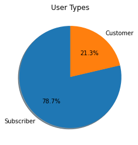

```python
#Distribution of type of users
data = df_clean['user_type'].value_counts()/df_clean['user_type'].value_counts().sum()
plt.pie(data, labels = data.index, autopct='%1.1f%%', shadow = 'True' , startangle = 90)
plt.title('User Types');
```

### Duration Of Rides

```python
#Looking at the duration statistics
df_clean['duration_sec'].describe()
```

```
count    1.235218e+07
mean     9.058074e+02
std      6.130849e+03
min      0.000000e+00
25%      3.630000e+02
50%      5.810000e+02
75%      9.180000e+02
max      3.283732e+06
Name: duration_sec, dtype: float64
```

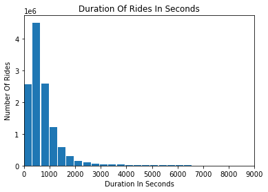

```python
#Distribution of duration of rides
data = df_clean['duration_sec']
plt.hist(data , bins = 10000 , rwidth=.9)
plt.xlim(0,9000)
plt.title('Duration Of Rides In Seconds')
plt.xlabel('Duration In Seconds')
plt.ylabel('Number Of Rides');
```

From the statistics, we can observe that there are outliers in the duration of rides due to the maximum duration being an extremely high number. By looking at the graph we can conclude that the majority of the rides are under 16 minutes.

### Number Of Rides By Different Measures Of Time

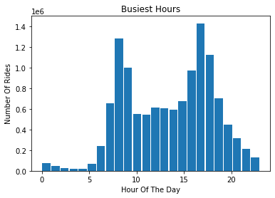

```python
#Distribution of number of rides by hours of the day
data = df_clean['start_time'].dt.hour
plt.hist(data,rwidth=.9, bins = 24)
plt.title('Busiest Hours')
plt.xlabel('Hour Of The Day')
plt.ylabel('Number Of Rides');
```

As expected the distribution is bimodal. The two peaks are during the normal rush hours of a day. The first between the hours of 7AM and 9AM when people are going to work. And the second peak is between the hours of 4PM and 6PM when people are getting off of work.

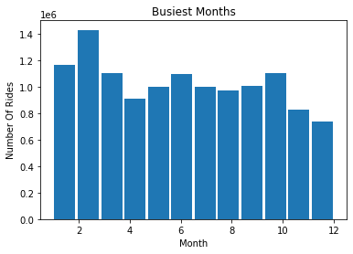

```python
#Distribution of rides per months
data = df_clean['start_time'].dt.month
plt.hist(data,rwidth=.9, bins = 12)
plt.title('Busiest Months')
plt.xlabel('Month')
plt.ylabel('Number Of Rides');
```

According to the distribution the busiest month has been February. Where the lowest have been November and December. Which could be due to less people at work due to the holidays. We will check this distribution by year later on.

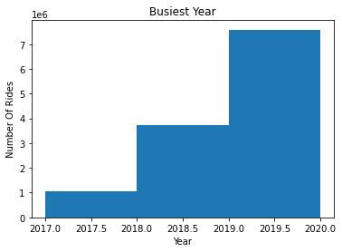

```python
#Distribution of rides per year
data = df_clean['start_time'].dt.year
plt.hist(data, bins = 3)
plt.title('Busiest Year')
plt.xlabel('Year')
plt.ylabel('Number Of Rides');
```

We can observe a gradual increase of rides throughout the years which is very positive to continue business.

### Discuss the distribution(s) of your variable(s) of interest. Were there any unusual points? Did you need to perform any transformations?

Most of the distributions we found were expected. From the majority users being subscribers, to the busiest hours being during the rush hour time of the day and how business has gradually increased every year. The unusual point we have found however is the distribution of rides when we look at each month. I did not expect the busiest month to be February. Which is something I look at a little bit deeper later on. There was no need to perform any transformations.

# Bivariate Exploration

In this section I will investigate relationships between pairs of variables in our data.

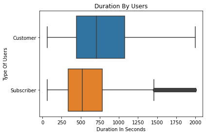

```python
#Distribution of the duration by users
majority = df_clean[df_clean['duration_sec'] < 2000]
sns.boxplot(data =majority , y='user_type', x='duration_sec')
plt.title('Duration By Users')
plt.xlabel('Duration In Seconds')
plt.ylabel('Type Of Users');
```

The distribution shows us that customers on average take a longer trip than subscribers.

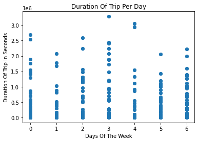

```python
#Distribution of duration trips per day
df_clean['daysofweek'] = df_clean['start_time'].dt.dayofweek

plt.scatter(data = df_clean , x = 'daysofweek' , y='duration_sec')
plt.title('Duration Of Trip Per Day')
plt.xlabel('Days Of The Week')
plt.ylabel('Duration Of Trip In Seconds');
```

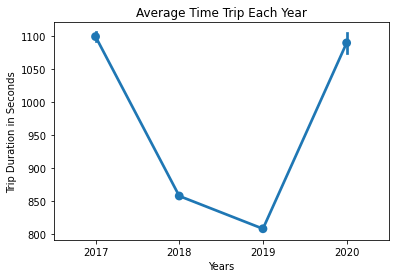

```python
#Distribution of duration of trips by year
df_clean['year'] = df_clean['start_time'].dt.year
ax = sns.pointplot(data=df_clean, x='year' , y='duration_sec')
plt.xlabel('Years')
plt.ylabel('Trip Duration in Seconds')
plt.title('Average Time Trip Each Year');
```

The distribution is a little bit of a worry considering that the duration has not been consistent. This year has been a good year so far however. The longer the trips are, the more money the company gets of course.

### Discuss the distribution(s) of your variable(s) of interest. Were there any unusual points? Did you need to perform any transformations?

From the distribution I have seen that the subscribers on average take shorter trip. A reason might be because these subscribers are people that work in the city and only take the bike for the convenience. Whereas a customer might be tourists that are sightseeing and would then travel longer distances.

And the duration throughout the years has not been consistent with the year of 2018 and 2019 being the lowest so far.

# Multivariate Exploration

In this section I will create plots of three or more variables to investigate the data even further.

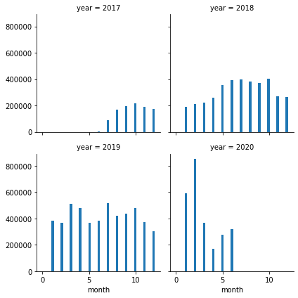

```python
#Distribution of rides by months and year
df_clean['month'] = df_clean['start_time'].dt.month
g = sns.FacetGrid (data = df_clean, col='year', col_wrap=2)
bins = np.linspace(0,12)
g.map(plt.hist, "month" , bins=bins);
```

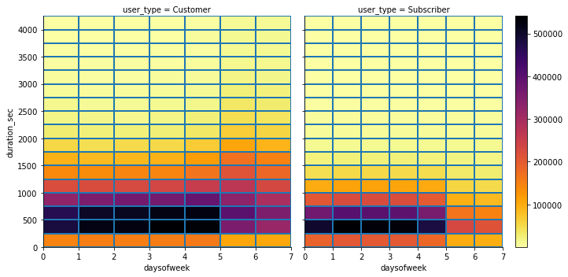

```python
#Distribution of the duration per trip in the week by subscribers
xbin = np.arange(0,7+1,1)
ybin = np.arange(0,4200+250,250)

g = sns.FacetGrid (data = df_clean , col='user_type', height=5)
g.map(plt.hist2d, 'daysofweek', 'duration_sec', cmin=0.5, cmap = 'inferno_r', bins=[xbin,ybin])
plt.colorbar();
```

From this heatmap we can similarities between customers and subscribers. We can see that both have an average of 4 and 12 min rides during the week. However customers are not only more present during the weekend they take longer trips as well.

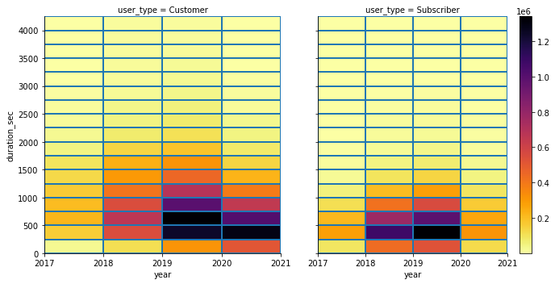

```python
#Distribution of the duration per trip by years and subscribers
df_clean['year'] = df_clean['start_time'].dt.year
xbin = np.arange(2017,2021+1,1)
ybin = np.arange(0,4200+250,250)

g = sns.FacetGrid (data = df_clean , col='user_type', height=5)
g.map(plt.hist2d, 'year', 'duration_sec', cmin=0.5, cmap = 'inferno_r', bins=[xbin,ybin])
ticks = [2017,2018,2019,2020,2021]
g.set(xticks = ticks, xticklabels = ticks);
plt.colorbar();
```

From the heatmap we see an abnormal trend. We do see that the duration for customers is higher than for the subscribers. However, for the year of 2020 it seems that subscribers have used the bikes a lot less compared to the customers. This might be because of covid-19 where people have worked from home a lot more.

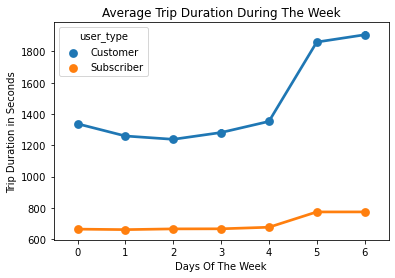

```python
#Distribution of duration for a trip by days and user types
ax = sns.pointplot(data=df_clean, x='daysofweek' , y='duration_sec', hue='user_type')
plt.xlabel('Days Of The Week')
plt.ylabel('Trip Duration in Seconds')
plt.title('Average Trip Duration During The Week');
```

This graph is as expected where the duration for a trip is longer during the weekends than weekdays.

### Discuss the distribution(s) of your variable(s) of interest. Were there any unusual points? Did you need to perform any transformations?

We have seen that customers take longer rides from subscribers. Because most customers are tourists and will travel longer distances to the see the city. What was abnormal was the distribution for the year of 2020, where it seemed that customers were more active than subscribers. Which might be due to the health climate of the world in the past couple months.